# レポート課題 第5回 課題１

氏名：木澤 祐人  
学籍番号：2094572t

## Googleドライブのマウントとフォルダへの移動

```python
from google.colab import drive
drive.mount('/content/drive')
%cd /content/drive/'My Drive'/情報管理/05/
```

```
/content/drive/My Drive/情報管理/05
```

## 必要なライブラリのインポート

```python
import pandas as pd
import numpy as np
import matplotlib.pyplot as plt
```

## データの読み込み

今回用いるデータ " car.csv " を読み込む。

```python
csv_data = pd.read_csv('car.csv', encoding='SHIFT-JIS')
display(csv_data.head())

X = csv_data.to_numpy()

(num_samples, num_dimensions) = np.shape(X)
print('Nunber of samples: ' + str(num_samples))
print('Number of dimensions: ' + str(num_dimensions))
```

|  | 燃費 | 車体重量 | 排気量 | 馬力 | 耐久年数 |
| --- | --- | --- | --- | --- | --- |
| 0 | 33 | 2560 | 97 | 113 | 12 |
| 1 | 33 | 2345 | 114 | 90 | 8 |
| 2 | 37 | 1845 | 81 | 63 | 12 |
| 3 | 32 | 2260 | 91 | 92 | 13 |
| 4 | 32 | 2440 | 113 | 103 | 13 |

```
Nunber of samples: 49
Number of dimensions: 5
```

データが `X` に格納された。  
今回、  
`Number of samples` はデータ内のサンプル数，つまり車の数を表し、  
`Number of dimensions` は1サンプルの次元数，つまり評価する性能の種類である。  
したがって、このデータは5次元ベクトルが49サンプル格納されたデータということになる。 この5次元ベクトルデータを主成分分析により2次元に圧縮し，プロットする。

## データの標準化

今回の分析対象のデータでは、評価する性能が様々であるため、各次元のスケール、すなわち単位がそろっていない。  
このまま分析を進めてしまうと想定通りの分析が行えない可能性がある。  
そこで、スケールを合わせるための前処理として，各次元の平均と分散で正規化を行う。

```python
mu = np.mean(X, axis=0)
std = np.std(X, axis=0)

X_norm = (X - mu) / std
```

## 分散共分散行列の計算

標準化したデータの分散共分散行列を計算する。

```python
cov = np.cov(X_norm.T, bias=True)
print(cov)
```

```
[[ 1.         -0.83412205 -0.72763669 -0.71739273  0.3055864 ]
 [-0.83412205  1.          0.8379101   0.82208973 -0.2561709 ]
 [-0.72763669  0.8379101   1.          0.81160803 -0.46228596]
 [-0.71739273  0.82208973  0.81160803  1.         -0.17803832]
 [ 0.3055864  -0.2561709  -0.46228596 -0.17803832  1.        ]]
```

## 分散共分散行列の固有値分解

次に、主成分分析を実行するため、分散共分散行列を固有値分解し，固有値の大きい順に固有ベクトルを並べ替える。

```python
eig_val, eig_vec =np.linalg.eig(cov)
eig_val = np.real(eig_val)
eig_vec = np.real(eig_vec)

order = np.argsort(eig_val)[::-1]
eig_val = eig_val[order]
eig_vec = eig_vec[:,order]
print('Eigen values:')
print(eig_val)
print('Eigen vectors:')
print(eig_vec)
```

```
Eigen values:
[3.52102407 0.91331336 0.31051856 0.15103757 0.10410645]
Eigen vectors:
[[-0.47229251  0.09586292  0.77222845  0.26061953 -0.32169981]
 [ 0.50002281 -0.18187891 -0.12058756  0.50177368 -0.67125186]
 [ 0.49785818  0.09235601  0.39559205  0.45609188  0.61570669]
 [ 0.47417345 -0.26943959  0.48230842 -0.66685046 -0.1589053 ]
 [-0.23283845 -0.93627082  0.00271581  0.16610626  0.20392291]]
```

## 主成分分析による次元圧縮

第一主成分および第二主成分の固有ベクトルを使って，データを二次元に圧縮する。

```python
X_pca = np.dot(X_norm, eig_vec[:,:2])

(num_samples_pca, num_dimensions_pca) = np.shape(X_pca)
```

主成分分析により，データが5次元から2次元に圧縮された。

次に，横軸を第一主成分，縦軸を第二主成分として，2次元に圧縮したデータをプロットする。

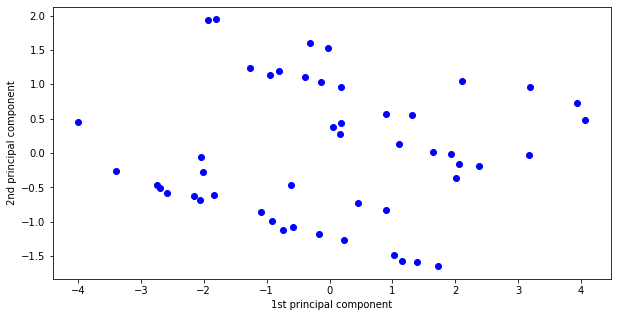

```python
plt.figure(figsize=(10,5))
plt.scatter(X_pca[:,0], X_pca[:,1], color='b')
plt.xlabel('1st principal component')
plt.ylabel('2nd principal component')
plt.show()
```

## 各主成分の考察

第1主成分と第2主成分がそれぞれ何を表す軸なのかを考察する。

まず，第一主成分と第二主成分の固有ベクトル，つまり圧縮時に用いる各次元の係数を見る。

```python
print('Coefficients for the 1st principal component')
print(eig_vec[:,0])

print('Coefficients for the 2nd principal component')
print(eig_vec[:,1])
```

```
Coefficients for the 1st principal component
[-0.47229251  0.50002281  0.49785818  0.47417345 -0.23283845]
Coefficients for the 2nd principal component
[ 0.09586292 -0.18187891  0.09235601 -0.26943959 -0.93627082]
```

したがって、

第一主成分は，  
-0.47*燃費 + 0.50*車体重量 + 0.50*排気量 + 0.47*馬力 - 0.23*耐久年数  
として計算されている。  
車体重量・排気量・馬力には正の係数、燃費と耐久年数には負の係数がかけられており、前者の３つが大きいほど第１主成分は正の方向へ、後者の２つが大きいほど負の方向へ大きくなることがわかる。 また、係数の絶対値が耐久年数のみほかの４つの半分以下となっており、比重が小さくなっている。

第二主成分は， 0.10*燃費 - 0.18*車体重量 + 0.09*排気量 - 0.27*馬力 - 0.94*耐久年数 として計算されている。  
こちらの主成分では、燃費・排気量には正の係数、車体重量・馬力・耐久年数には負の係数がかけられており、前者の２つが大きいほど第２主成分は正の方向へ、後者の３つが大きいほど負の方向へ大きくなることがわかる。 また、耐久年数の係数の絶対値が他の係数の3倍以上となっており、非常に大きな比重で計算されていると言える。

車体重量・排気量・馬力の平均と燃費・耐久年数の平均の割合を計算することで，前者の割合が高い程赤く，後者の割合が高いほど青くなるように散布図の色を変えてプロットすると次のようになる。

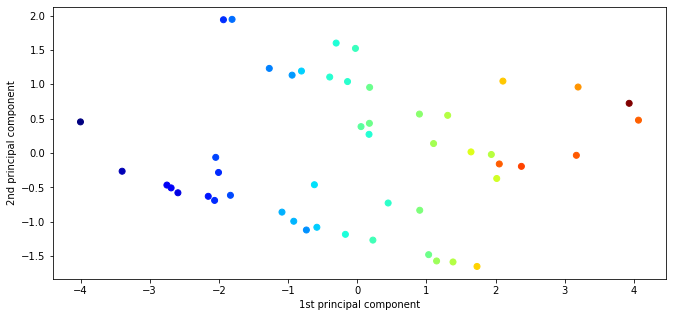

```python
tmp = X[:,[3, 1, 2, 0, 4]]

color = np.mean(tmp[:,:3],axis=1) / np.mean(tmp[:,3:], axis=1)

plt.figure(figsize=(11,5))
plt.scatter(X_pca[:,0], X_pca[:,1], c=color, cmap='jet')
plt.xlabel('1st principal component')
plt.ylabel('2nd principal component')
plt.show()
```

上の図によると，車体重量・排気量・馬力の割合が高いほど右に，燃費・耐久年数の割合が高いほど左に分布していることが分かる。  
前者３つの要素は主にレース向けの車において重要であるのに対し、後者２つは日常生活での利用に大切な指標であると言える。  
このことから，**第１主成分は車の使用用途と関係が強い軸が作られている**ことが分かる。

次に、耐久年数が長い方が赤く、短い方が青くなるようプロットすると次のようになる。

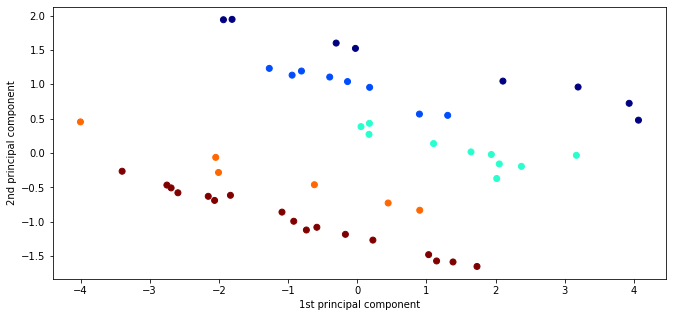

```python
color = np.sum(X[:,4:5],axis=1)

plt.figure(figsize=(11,5))
plt.scatter(X_pca[:,0], X_pca[:,1], c=color, cmap='jet')
plt.xlabel('1st principal component')
plt.ylabel('2nd principal component')
plt.show()
```

上の図によると，耐久年数が短いほど上に、長いほど下に分布していることが分かる。  
このことから，**第２主成分は車の耐久年数の短さと関係性が強い軸が作られている**ことが分かる。